# Forecasting with Time Series Data

Steve Elston

11/20/2023

## Why Are Time Series Useful?

- Data are often time-ordered
- Estimates 30% of data science problems include time series data
- Must use specific time series models

## Why Are Time Series Useful?

“It’s tough to make predictions, especially about the future!”

Karl Kristian Steincke, Danish politician, ca 1937

- **Demand forecasting:** Electricity production, Internet bandwidth, Traffic management, Inventory management, sales forecasting
- **Medicine:** Time dependent treatment effects, EKG, EEG
- **Engineering and Science:** Signal analysis, Analysis of physical processes
- **Capital markets and economics:** Seasonal unemployment, Price/return series, Risk analysis

## Why Are Time Series Data Different?

Models must account for time series behavior

- Most statistical and machine learning assume data samples are **independent identically distributed (iid)**
- But, this is not the case for time series data
- Time series values are correlated in time
- Time series data exhibit **Serial correlation**
  - Serial correlation of values
  - Serial correlation of errors
  - Violate iid assumptions of many statistical and ML Models  
    `

## Properties of Time Series

Fundamental elements of time series

- Fundamental components which cannot be predicted
  - White noise
  - Random walks
- Autocorrelation and partial autocorrelation
- Trend
- Seasonal components
- Differencing to transform to stationarity
  - Seasonal differencing
  - Non-seasonal differencing
- Stationarity properties
  - augmented Dicky-Fuller test
  - KPSS test

## Time Series Forecasting Models

**Forecasting** is the goal of much of time series analysis

- ARIMA and SARIMAX models; time series linear models
- For comprehensive introduction see [Forecasting: Principles and Practice, Hyndman and Athanaosopoulos, 3rd edition, 2018](https://otexts.com/fpp2/), available as book or free online
- [Rob Hyndman’s blog](https://robjhyndman.com/hyndsight/) is a source of many interesting ideas and example in time series analysis

## Tine Series Models

The **ARIMA model** is composed three components:

- **Autoregressive component (AR)** accounts for partial autocorrelation
  - Serial correlation of observatons
- **Integrative component (I)** accounts random walks and trend
- **Moving Average (MA)** accounts for autocorrelation
  - Serial correlation of model error
- **SARIMAX** model adds:
  - **Seasonal components (S)**
  - **Exogenous variables (X)**

## Time Series Models

Many types of time series models

- **SARIMA**: seasonal autoregressive integrative moving average, adds seasonal components
  - **seasonal AR** accounts for serial correlation of seasonal values
  - **seasonal I** component accounts for random walk and trend of seasonal components
  - **seasonal MA** accounts for seasonal serial correlation of errors
- **SARIMAX:** seasonal autoregressive integrative moving average with **exogenous variables**
  - Add effect of external factors
  - Example; effect of specific holiday
  - Example; effect arising from factors not incorporated in endogenous variable

## The Autoregressive Model

**Autoregressive model** relates past observed values to the current value

- An autoregressive model of order $p$, $AR(p)$, uses the last p observations:

$$\begin{align}
y_t &= \phi_1 y_{t-1} + \phi_2 y_{t-2} + \ldots + \phi_p y_{t-p} +
w_t\\
&where\\
\phi_k &= model\ coefficient\ at\ lag\ k\\
w_t &= white\ noise\ error\ at\ time\ t;\ \sim
\mathtt{N}(0,\sigma^2)\\
y_t &= observation\ at\ time\ t\\
\end{align}$$

- An AR process has the following properties:
  - $\rho_0 = 1$ always
  - $p_k = \phi_k$
  - Number of nonzero PACF values $= p$
  - A shock at any time will affect the result as $t \rightarrow \infty$
- AR model assume stationary time series

## The Autoregressive Model

How can we understand the AR model?

- Consider an AR(2) model
- The value of $y_t$ is a weighted sum of $k$ previous values plus an error term

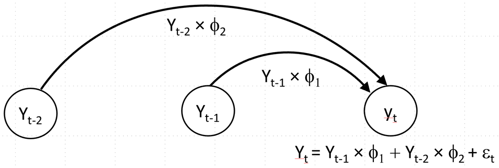

Illustration of the AR(2) model

## The Autoregressive Model

How can we understand the AR model?

- Model matrix of AR(2) model

$$A =
\begin{bmatrix}
y_t,\ y_{t-1},\ y_{t-2}\\
y_{t-1},\ y_{t-2},\ y_{t-3}\\
y_{t-2},\ y_{t-3},\ y_{t-4}\\
\vdots,\ \ \ \ \ \vdots,\ \ \ \ \ \vdots\\
y_{2},\ \ \ \ y_{1},\ \ \ \ y_{0}\\
y_{1},\ \ \ \ y_{0}\ \ \ \, 0\\
y_0,\ \ \ \ 0,\ \ \ \ 0
\end{bmatrix}$$

- AR model is a **linear model!**
- For coefficient vector, $\Phi = [\phi_1, \phi_2, \ldots, \phi_p]$, solve linear system:

$$Y = A \Phi$$

## The Autoregressive Model

We can rewrite the AR(1) model in terms of exceptions:

$$\begin{align}
\mathbb{E}(y_t) &= \phi \mathbb{E}(y_{t-1}) + \mathbb{E}(\epsilon_t)
\\
&or \\
\mu &= c + \phi \mu + 0 \\
&therefore \\
\mu &= \frac{c}{1 - \phi}
\end{align}$$

$$y_t = \sum_{i=1}^t w_i$$

## The Autoregressive Model

Example of AR(2) time series with coefficients $= (1.0, 0.75, 0.25)$:

- Time series looks a bit random
- But, notice the statistical properties; ACF, PACF
- PACF has 2 non-zero lag values, so $p=2$

```
## Is the time series stationary? True
## Is the time series invertable? True
```

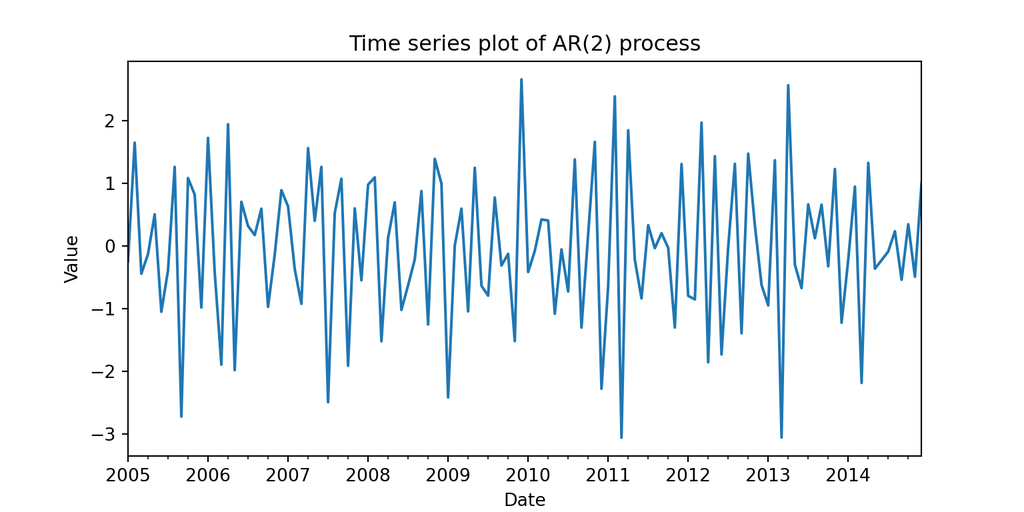

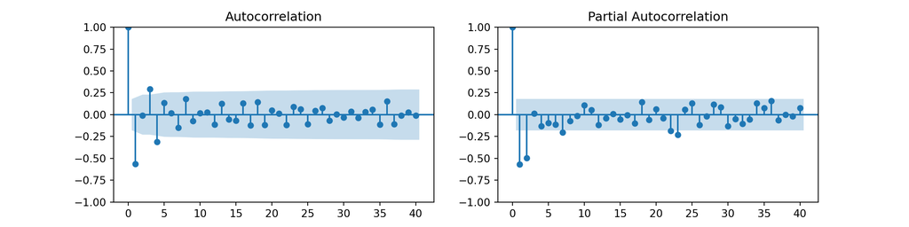

## The Autoregressive Model

Example model summary for $AR(0.75, 0.25)$ model:

- Both AR coefficients are statistically significant
- Variance term is statistically significant

```
##                                SARIMAX Results
## ==============================================================================
## Dep. Variable:                      y   No. Observations:                  120
## Model:                 ARIMA(2, 0, 0)   Log Likelihood                -152.398
## Date:                Fri, 16 Aug 2024   AIC                            312.795
## Time:                        16:35:43   BIC                            323.945
## Sample:                    01-31-2005   HQIC                           317.323
##                          - 12-31-2014
## Covariance Type:                  opg
## ==============================================================================
##                  coef    std err          z      P>|z|      [0.025      0.975]
## ------------------------------------------------------------------------------
## const         -0.0299      0.035     -0.862      0.389      -0.098       0.038
## ar.L1         -0.8445      0.079    -10.688      0.000      -0.999      -0.690
## ar.L2         -0.4922      0.091     -5.419      0.000      -0.670      -0.314
## sigma2         0.7366      0.105      7.021      0.000       0.531       0.942
## ===================================================================================
## Ljung-Box (L1) (Q):                   0.00   Jarque-Bera (JB):                 0.32
## Prob(Q):                              0.98   Prob(JB):                         0.85
## Heteroskedasticity (H):               0.69   Skew:                            -0.06
## Prob(H) (two-sided):                  0.24   Kurtosis:                         2.77
## ===================================================================================
##
## Warnings:
## [1] Covariance matrix calculated using the outer product of gradients (complex-step).
```

## The Moving Average Model

A **moving average** model of order $q$, $MA(q)$, uses the last q error terms or shocks:

$$\begin{align}
y_t &= \mu + \epsilon_t + \theta_1 \epsilon_{t-1} + \theta_2
\epsilon_{t-2} + \cdots + \theta_q \epsilon_{t-q}\\
&where\\
\theta_k &= model\ coefficient\ at\ lag\ k\\
y_t &= observation\ at\ time\ t\\
\epsilon_t &= innovation\ or\ error\ at\ time\ t;\ \sim
\mathtt{N}(0,\sigma^2)
\end{align}$$

- An MA process has the following properties:
  - For autocorrelation, $\rho_0 = 1$ always
  - Number of $\rho_k \ne 0$, $= q$
  - Shocks die off quickly in MA processes
- MA model assumes stationary time series

## The Moving Average Model

A **moving average** model of order $q$, $MA(q)$, uses the last q error terms or shocks:

$$y_t = \mu + \epsilon_t + \theta_1
\epsilon_{t-1} + \theta_2 \epsilon_{t-2} + \cdots + \theta_q
\epsilon_{t-q}$$

We can also write the MA model in terms of estimated value, $\hat{y}_t$:

$$\begin{align}
\hat{y}_t &= \mu + \theta_1 \epsilon_{t-1} + \theta_2 \epsilon_{t-2}
+ \cdots + \theta_q \epsilon_{t-q}\\
& Therefore,\\
\epsilon_t &= y_t - \hat{y}_t \sim \mathtt{N}(0,\sigma^2);\ error\
at\ time\ t \\
\end{align}$$

## The Moving Average Model

How can we understand the MA model?

- Model matrix of MA(2) model

$$A =
\begin{bmatrix}
y_t,\ \epsilon_{t-1},\ \epsilon_{t-2}\\
y_{t-1},\ \epsilon_{t-2},\ \epsilon_{t-3}\\
y_{t-2},\ \epsilon_{t-3},\ \epsilon_{t-4}\\
\vdots,\ \ \ \ \ \vdots,\ \ \ \ \ \vdots\\
y_{2},\ \ \ \ \epsilon_{1},\ \ \ \ \epsilon_{0}\\
y_{1},\ \ \ \ \epsilon_{0}\ \ \ \, 0\\
y_0,\ \ \ \ 0,\ \ \ \ 0
\end{bmatrix}$$

- MA model is a **nonlinear model!**; must compute $\epsilon_{t}$ at each time step
- The value of $\epsilon_t$ dependents on $[ \epsilon_{t-1}, \epsilon_{t-2}, ..., \epsilon_{t-q}]$
- The $\epsilon_k$s are **unobservable**!
- So, fitting requires **nonlinear iteratively rewieighted least squares**

## The Moving Average Model

Example of an MA(1) model with coefficients $(1, -0.75)$

- The time series looks fairly random
- The ACF has 1 statistically significant nonzero lag value

```
## Is the time series stationary? True
## Is the time series invertable? True
```

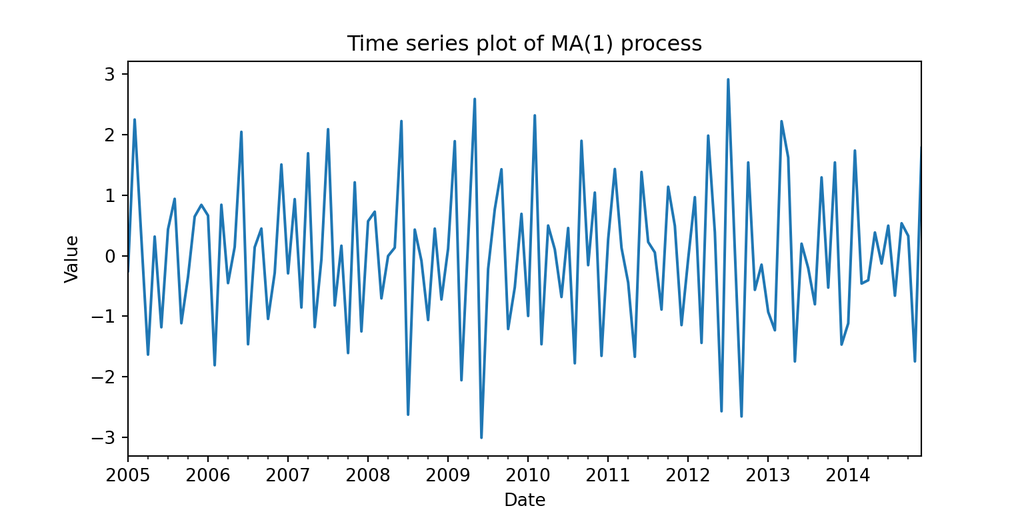

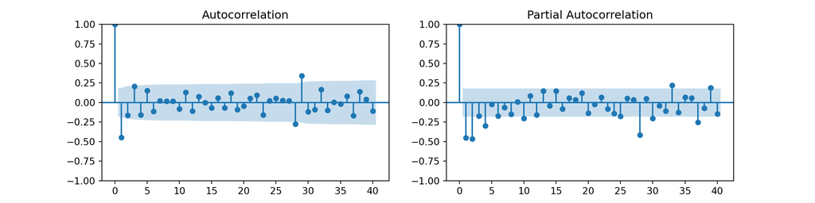

## The Moving Average Model

Example model summary for $MA(-0.75)$ model:

- The MA coefficient is statistically significant
- Notice that true value is within the confidence interval
- Confidence interval is wide

```
##                                SARIMAX Results
## ==============================================================================
## Dep. Variable:                      y   No. Observations:                  120
## Model:                 ARIMA(0, 0, 1)   Log Likelihood                -162.751
## Date:                Fri, 16 Aug 2024   AIC                            331.502
## Time:                        16:35:44   BIC                            339.864
## Sample:                    01-31-2005   HQIC                           334.898
##                          - 12-31-2014
## Covariance Type:                  opg
## ==============================================================================
##                  coef    std err          z      P>|z|      [0.025      0.975]
## ------------------------------------------------------------------------------
## const          0.0214      0.015      1.395      0.163      -0.009       0.051
## ma.L1         -0.8303      0.049    -17.024      0.000      -0.926      -0.735
## sigma2         0.8736      0.126      6.936      0.000       0.627       1.120
## ===================================================================================
## Ljung-Box (L1) (Q):                   0.11   Jarque-Bera (JB):                 1.59
## Prob(Q):                              0.74   Prob(JB):                         0.45
## Heteroskedasticity (H):               1.12   Skew:                             0.21
## Prob(H) (two-sided):                  0.71   Kurtosis:                         2.63
## ===================================================================================
##
## Warnings:
## [1] Covariance matrix calculated using the outer product of gradients (complex-step).
```

## Autoregressive Moving Average Model

We can combine AR and MA terms to create the **autoregressive moving average (ARMA)** model of order $(p,q)$:

$$y_t = \phi_1 y_{t-1} + \phi_2 y_{t-2}
,\ldots, + \phi_p y_{t-p} +
\epsilon_t + \theta_1 \epsilon_{t-1} + \theta_2 \epsilon_{t-2} + \cdots
+ \theta_q \epsilon_{t-q}$$

- Fit ARMA model by solving a nonlinear equatioin:

$$y_t - \phi_1 y_{t-1} - \phi_2 y_{t-2}
,\ldots, - \phi_p y_{t-p} =
\epsilon_t + \theta_1 \epsilon_{t-1} + \theta_2 \epsilon_{t-2} + \cdots
+ \theta_q \epsilon_{t-q}$$

- Can write as polynomial equation in terms of coefficient vectors $\Phi = [1, \phi_1, \phi_2, \ldots, \phi_p ]$, $\Theta = [1, \theta_1, \theta_2, \cdots, \theta_q]$:
  $$(1-\Phi)Y = \Theta
  \epsilon$$
- ARMA model assumes stationary time series

## The ARIMA Model

The integrative model addresses certain non-stationary components of a time series

- Random walks
- Trends
- Based on difference operator
  - Typically first order difference
  - Seasonal and non-seasonal differences
  - Is deterministic, no model coefficient to estimate

## The ARIMA Model

The **autoregressive integrative moving average (ARIMA)** model includes AR, integrative and MA terms

- The order of an ARIMA is specified as (p,d,q)
  - p is the AR order
  - d is the order of differencing
  - q is the MA order
- The integrative term helps transforms trend and random walks to stationary process
- Does not account for seasonal effect

## The ARIMA Model

The **autoregressive integrative moving average (ARIMA)** model includes AR, integrative and MA terms

- Formulate an $ARIMA(1,1,1)$ model
- Start with $ARMA(1,1) = ARIMA(1,0,1)$ model:

$$y_t - c - \phi_1 y_{t-1} = \epsilon_t
+ \theta_1 \epsilon_{t-1}$$

- Take the first difference of the observations, $y_i$, to find the formulation of the $ARIMA(1,1,1)$ model.

$$y_t - y_{t-1} - \phi_1( y_{t-1} -
y_{t-2}) = \epsilon_t + \theta_1 \epsilon_{t-1}$$

- Applied same algebra to finding polynomial formulations for higher order ARIMA models.

## Seasonal Models

Several possible seasonal models

- Seasonal effects can be periodic or single event (e.g. holiday, game day, etc.)
- Linear regression model to find effect for each time step in period
- STL decomposition
- Fourier decomposition
  - Flexible
  - Accommodates multiple periods of seasonality
  - Used by PROFIT model, [Statsmodels](https://www.statsmodels.org/dev/examples/notebooks/generated/statespace_seasonal.html) and others
- SARIMAX, the S term
- Each model requires:
  - Known period of the cycle or time of seasonal event
  - Additive or logarithmic transformation

## SARIMAX Model

The SARIMAX model adds seasonal and exogenous terms

- ARIMA terms are same, (p,d,q)
- Seasonal terms:
  - ARIMA seasonal model, order (P,D,Q,S)
  - Must specify period, S, seasonal difference order, D
- Order of SARIMAX model is specified as (p,d,q)(P,D,Q,S)
- See [Statsmodels State Space User Guide](https://www.statsmodels.org/dev/examples/notebooks/generated/statespace_sarimax_stata.html) for more details and examples

## SARIMAX Model

SARIMA model can be formulated as an additive or a multiplicative model of the components of a non-seasonal ARIMA model and the seasonal ARIMA model

- Additive model can be expressed: $SARIMA \big[ (p,d,q) + (P,D,Q,S) \big]$
- Multiplicative model can be expressed: $SARIMA \big[ (p,d,q)(P,D,Q,S) \big]$
- Example, a multiplicative $SARIMA(1,1,1)(1,1,1,S)$ model:

$$(y_t - \phi_1 y_{t-1})(y_t - \Phi_1
y_{t-S})(1-y_{t-1})(y_t - y_{t-S}) = (\epsilon_t - \theta_1
\epsilon_{t-1})(\epsilon_t - \Theta_1 \epsilon_{t-S})$$

- Continue same algebra to find the polynomial of any $(p,d,q)(P,D,Q,S)$ order

## SARIMAX Model

The SARIMAX model (with no exogenous variables) is formulated

$$\phi_p(Y) \tilde{\phi}_P(Y^*) \nabla^d \nabla^D y_t = A(t) +
\theta_q(Y) \tilde{\theta}_Q(Y^*)$$

- $\phi_p(Y)$ and $\tilde{\phi}_P(Y^*)$ are the AR polynomials non-seasonal and seasonal terms
- $\theta_q(Y)$ and $\tilde{\theta}_Q(Y^*)$ are the MA polynomials non-seasonal and seasonal terms
- $\nabla^d$ and $\nabla^D$ are the non-seasonal and seasonal differencing operators
- $A(t)$ is the trend term

## SARIMAX Model

SARIMAX model can include exogenous variables, $x$, leading to a new system of equations”:

$$y_t = \beta_t x_t + \mu_t \\
\phi_p(Y) \tilde{\phi}_P(Y^*) \nabla^d \nabla^D \mu_t = A(t) +
\theta_p(Y) \tilde{\theta}_P(Y^*)$$

- Time series model for latent variable, $\mu_t$
- $\mu_t$ acts as the intercept term for the regression model for $x_t$
- The coefficient vector, $\beta$, contains the **effect sizes** for the exogenous variables

## Forecasting with the ARIMA model

Goal of forecasting is to compute a point estimates, $\hat{y}_{t+H}$, $H$ time steps in the future

- Use the time series history, $[y_t, y_{t-1}, y_{t-2}, \ldots]$
- Example, compute a forecast for a stationary time series with an ARIMA$(p,d,q)$ model
- Recursively apply a one step ahead forecast
- For the forecasted value $\hat{y}_{t+H}$ we have no estimated error:

$$\epsilon_{t+H} = y_{t+H} -
\hat{y}_{t+H}$$

## Forecasting with the ARIMA model

Goal of forecasting is to compute a point estimates, $\hat{y}_{t+H}$, $H$ time steps in the future

- Example, make a forecast with an ARIMA(2,1,1) model:

$$y_t - y_{t-1} - \phi_1( y_{t-1} -
y_{t-2}) - \phi_2 ( y_{t-2} - y_{t-3}) = \epsilon_t + \theta_1
\epsilon_{t-1}$$

- Model the one step ahead forecast as:

$$\hat{y}_{t+1}= y_{t} + \phi_1( y_{t} +
y_{t-1}) + \phi_1( y_{t-1} - y_{t-2}) + \theta_1
\epsilon_{t}$$

- Two step ahead forecast is computed using a recursive relationship

## Forecasting with the ARIMA model

Two step ahead forecast is computed using a recursive relationship

- But, no way to compute the error terms beyond the current observation at time $t$
- Replace $\epsilon_{t+1}$ with the last known residual as $e_{t+2} = e_t$:

$$\hat{y}_{t+2}= \hat{y}_{t+1} + \phi_1(
\hat{y}_{t+1} - y_{t}) + \phi_1( y_{t} - y_{t-1}) + \theta_1
e_{t}$$

- Take recursion one more step, set error terms, $\epsilon_i = 0$:

$$\hat{y}_{t+3}= \hat{y}_{t+2} + \phi_1(
\hat{y}_{t+2} - \hat{y}_{t+1}) + \phi_1( \hat{y}_{t+1} -
y_{t})$$

- Continue this recursion for as many time steps as desired
- Same algebra used to work out the forecasting axolynomial of higher order ARIMA model

## Evaluating and Comparing Time Series Models

How can we evaluate time series models?

- **Confidence intervals**
  - Fit to observations
  - Forecasts
- RMSE; compare forecast to actual values
  - Fit to observations
  - Forecasts
- Could use log-likelihood; $log \big(p(X|\theta) \big)$
  - $\theta = model\ parameters$
  - Use **score function** $= -2\ log(likelihood) = -2\ log \big(p(X|\theta) \big)$
  - But, score decreases with model complexity
- Need to adjust for number of model parameters
  - We always prefer simpler models; fewer parameters to learn
  - **Akaki Information Criteria (AIC)**
  - **Bayes Information Criteria (BIC)**

## Forecast Confidence Intervals

When presented with any forecast, the first question should be ‘what are the errors’?

- Forecast are a **extrapolations** of the model into the future
- Cannot use the residuals, $\epsilon_i$
  - Errors themselves must reflect the uncertainty beyond the range of available observations
- The forecast is a **point estimate**, which has a **confidence interval**. There are several ways which are commoinly used to compute confidence intervals:

## Forecast Confidence Intervals

Several ways which are commonly used to compute confidence intervals:

- **Theoretical sampling distribution:**
  - Compute confidence intervals from a theoretical sampling distribution
  - Deriving a suitable distribution can be difficult
  - Actual sampling distribution is invariably different
- **Bootstrap resampling:**
  - Use bootstrap resampling to compute a non-parametric sampling distribution
  - Bootstrap resampling of time series requires specific sampling methods
  - Confidence intervals are computed from emperical sampling distribution
- **Back-testing:**
  - Time series model is trained on a training portion of the data
  - Forecasts are made some time steps ahead, and errors calculated
  - Move the training and forecast windows
  - Sampling distribution and the confidence intervals are computed
  - Compute RMSE, MAE, etc. from the back test

## Evaluating and Comparing Time Series Models

Akaki Information criteria, AIC

$$\begin{align}
AIC &= 2\ k - 2\ ln(\hat{L})\\
&where\\
\hat{L} &= p(x| \hat\theta) = the\ likelihood\ given\ the\ fitted\
model\ parmaters\ \hat\theta \\
x &= observed\ data\\
k &= number\ of\ model\ parameters
\end{align}$$

- AIC penalizes the score function for the complexity of the model by $2\ k$
- Model with lowest AIC is best

## Evaluating and Comparing Time Series Models

Bayes Information criteria, BIC

$$\begin{align}
BIC &= ln(n)\ k- 2\ ln(\hat{L})\\
&where\\
\hat{L} &= p(x| \hat\theta) = the\ likelihood\ given\ the\ fitted\
model\ parmaters\ \hat\theta\\
x &= observed\ data\\
k &= number\ of\ model\ parameters\\
n &= number\ of\ observations
\end{align}$$

- BIC penalizes the score function for the complexity of the model, $k$
- BIC adjusts for number of samples used to learn the $k$ model parameters
- Model with lowest BIC is best
- BIC is often preferred to AIC for time series models

## Evaluating and Comparing Time Series Models

Can compare and select models using BIC or AIC

- Backwards step-wise model selection
  1. Start with initial order of the model; e.g. $(p,d,q)(P,D,Q,S)$
  2. Fit (learn) the model parameters
  3. compute the BIC, and if reduced consider this a better model
  4. Reduce the order of one of the model components
  5. Repeat steps 2, 3 and 4 until no further improvement
- Tips for comparing models:
  - BIC and AIC are approximations; small changes (3rd or 4th decimal) are not important
  - If close tie for best model pick the simpler (lower order) case
  - Often best to consider integrative terms, $d$ and $D$, separately

## SARIMAX Example

Example: 3 time series of Australian production

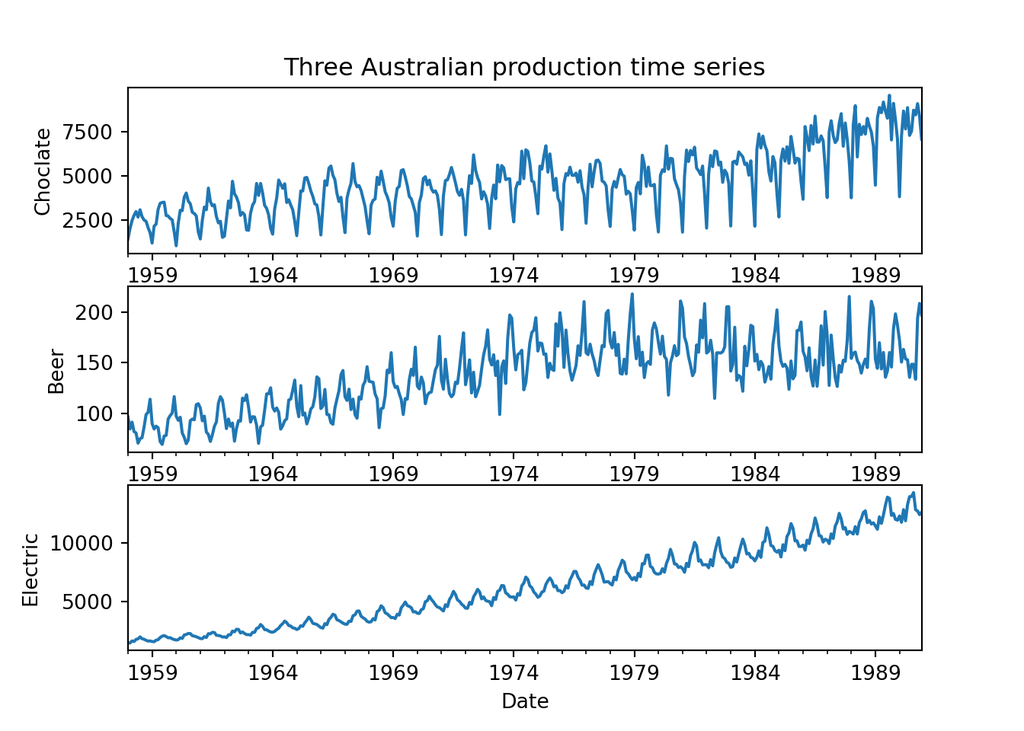

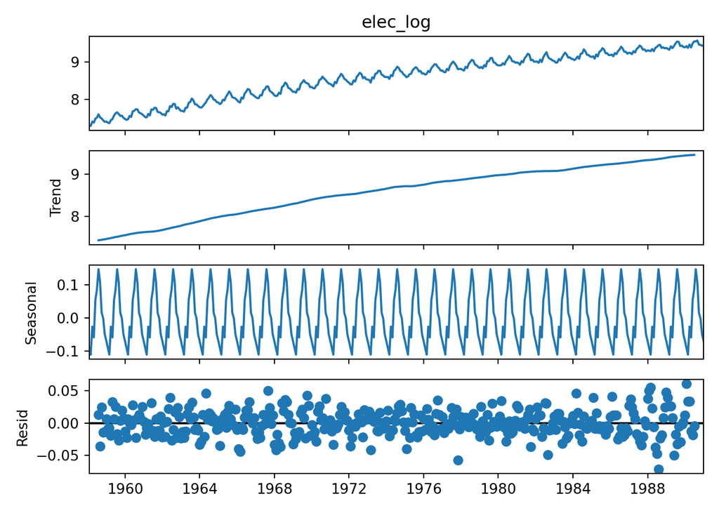

## SARIMAX Example

Use the SARIMAX model to find the best ARIMA fit of log(electric production)

```python
Log_electric = CBE.elec_log[:'1989-12-31']
best_model = pm.auto_arima(Log_electric, start_p=1, start_q=1,
                             max_p=3, max_q=3, m=12,
                             start_P=0, seasonal=True,
                             d=1, D=1, trace=True,
                             information_criterion = 'bic',
                             error_action='ignore',  # don't want to know if an order does not work
                             suppress_warnings=True,  # don't want convergence warnings
                             stepwise=True)  # set to stepwise
```

```
## Performing stepwise search to minimize bic
##  ARIMA(1,1,1)(0,1,1)[12]             : BIC=-1794.344, Time=0.70 sec
##  ARIMA(0,1,0)(0,1,0)[12]             : BIC=-1572.064, Time=0.06 sec
##  ARIMA(1,1,0)(1,1,0)[12]             : BIC=-1696.320, Time=0.36 sec
##  ARIMA(0,1,1)(0,1,1)[12]             : BIC=-1800.249, Time=0.77 sec
##  ARIMA(0,1,1)(0,1,0)[12]             : BIC=-1699.081, Time=0.07 sec
##  ARIMA(0,1,1)(1,1,1)[12]             : BIC=-1800.515, Time=1.07 sec
##  ARIMA(0,1,1)(1,1,0)[12]             : BIC=-1742.451, Time=0.25 sec
##  ARIMA(0,1,1)(2,1,1)[12]             : BIC=-1797.601, Time=3.02 sec
##  ARIMA(0,1,1)(1,1,2)[12]             : BIC=-1797.846, Time=3.40 sec
##  ARIMA(0,1,1)(0,1,2)[12]             : BIC=inf, Time=2.08 sec
##  ARIMA(0,1,1)(2,1,0)[12]             : BIC=-1770.861, Time=0.61 sec
##  ARIMA(0,1,1)(2,1,2)[12]             : BIC=-1791.556, Time=3.08 sec
##  ARIMA(0,1,0)(1,1,1)[12]             : BIC=inf, Time=0.49 sec
##  ARIMA(1,1,1)(1,1,1)[12]             : BIC=-1794.616, Time=1.24 sec
##  ARIMA(0,1,2)(1,1,1)[12]             : BIC=-1794.617, Time=0.91 sec
##  ARIMA(1,1,0)(1,1,1)[12]             : BIC=-1767.828, Time=0.93 sec
##  ARIMA(1,1,2)(1,1,1)[12]             : BIC=-1788.695, Time=1.29 sec
##  ARIMA(0,1,1)(1,1,1)[12] intercept   : BIC=-1792.517, Time=1.26 sec
##
## Best model:  ARIMA(0,1,1)(1,1,1)[12]
## Total fit time: 21.619 seconds
```

## SARIMAX Example

- Model selected by backwards step-wise method
- First order model integrative term and MA(1)
- First order model integrative term and MA(1) for period 12 seasonality

SARIMAX Results

| Dep. Variable: | y | No. Observations: | 384 |
| --- | --- | --- | --- |
| Model: | SARIMAX(0, 1, 1)x(1, 1, 1, 12) | Log Likelihood | 912.090 |
| Date: | Fri, 16 Aug 2024 | AIC | -1816.180 |
| Time: | 16:36:08 | BIC | -1800.515 |
| Sample: | 01-31-1958 | HQIC | -1809.958 |
|  | - 12-31-1989 |  |  |
| Covariance Type: | opg |  |  |

|  | coef | std err | z | P>\|z\| | [0.025 | 0.975] |
| --- | --- | --- | --- | --- | --- | --- |
| ma.L1 | -0.6389 | 0.039 | -16.433 | 0.000 | -0.715 | -0.563 |
| ar.S.L12 | 0.1787 | 0.087 | 2.051 | 0.040 | 0.008 | 0.350 |
| ma.S.L12 | -0.7912 | 0.061 | -13.075 | 0.000 | -0.910 | -0.673 |
| sigma2 | 0.0004 | 2.66e-05 | 15.729 | 0.000 | 0.000 | 0.000 |

| Ljung-Box (L1) (Q): | 0.00 | Jarque-Bera (JB): | 9.96 |
| --- | --- | --- | --- |
| Prob(Q): | 0.97 | Prob(JB): | 0.01 |
| Heteroskedasticity (H): | 1.01 | Skew: | -0.22 |
| Prob(H) (two-sided): | 0.95 | Kurtosis: | 3.67 |

Warnings:  
[1] Covariance matrix calculated using the outer product of gradients (complex-step).

## SARIMAX Example

Predictions for the last 12 months of the time series

```python
prediction = pd.Series(best_model.predict(n_periods=12),
                       index = pd.date_range(start = '1990-01-31', end = '1990-12-31', freq = 'M'))
```

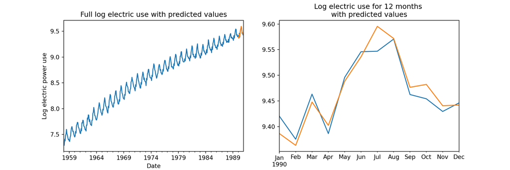

## SARIMAX Example

Residuals of the predictions

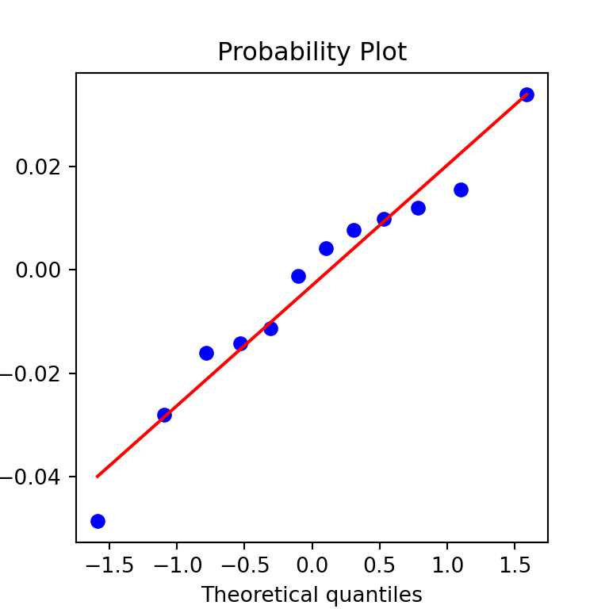

```python
residuals = CBE.elec_log['1990-01-31':] - prediction

fig, ax = plt.subplots(nrows=1, ncols=1, figsize=(4, 4))
_=ss.probplot(residuals, plot = ax);
plt.show()
```

## PROFIT Model

The PROFIT model from Meta Research is a **deterministic model** well suited for some business forecasting

- Uses a sophisticated piece-wise linear trend model
  - Trend computed between breakpoints
  - Breakpoints found with Bayesian model
  - Complex trend model **confounded by random walks**
- Multi-seasonal component modeled modeled by Fourier decomposition
  - Multiple harmonics per seasonal period
  - Flexible modeling of complex seasonal patterns
- Supports exogenous variables
- PROFIT model assumes residual is non-informative

## PROFIT Model

The PROFIT model from Meta Research is a **deterministic model** well suited for some business forecasting

- PROFIT model **assumes residual is non-informative**
  - ACF and PACF must have no significant nonzero lags
- If significant ACF and PACF use SARIMAX
  - Uses information in stationary residual
  - Gives **superior results for time series with stochastic components**

## Summary

Time series models must account for serial correlation

- e.g. ARIMA and SARIMAX
- AR components for serial correlation of values
- MA components for serial correlation of errors
- Integrative components for random walk and trend, I
- Seasonal, (P,D,Q,S)
- Exogenous variables, X

## Summary

Evaluation and model comparison

- RMSE
- AIC and BIC, penalize score function for model complexity
- Use BIC (or AIC) to perform backwards step-wise model selection

## Exponential Smoothing Models

[Exponential smoothing models](https://en.wikipedia.org/wiki/Exponential_smoothing) are simple and widely used

- Consider the simple first order model
- Set initial conditions:

$$s_0 = y_0$$

- The smoothed update is:

$$s_t = \alpha y_t + (1-\alpha) s_{t-1}\\
= s_{t-1} \alpha(y_t - s_{t-1}),\\
t \gt 0$$

- And, the smoothing coefficient is, $0 \le \alpha \le 1$
- But, model only works if no trend

## Exponential Smoothing Models

Decay and exponential smoothing

- We can understand the smoothing parameter $\alpha$ in terms of a **decay constant**, $\tau$

$$\alpha = 1 - e^{\big( \frac{\Delta
T}{\tau} \big)}$$

- An innovation or shock has an effect for all future time
- Effect decays exponentially with time, $\Delta T$

## Exponential Smoothing Models

Can extend exponential smoothing model to accommodate trend

- Algorithm known as **double exponential smoothing** or **Holt-Winters double exponential smoothing**
- Update smoothed values and slope at each time step
- Start with initial values

$$s_1 = y_1\\
b_1 = y_2 - y_1$$

- Update relationships for both smoothed value and slope

$$s_t = \alpha y_t + (1-\alpha) (s_{t-1} +
b_{t-1})\\
b_t = \beta(s_t - s_{t-1}) + (1 - \beta)b_{t-1}$$

- Additional slope smoothing hyperparameter, $0 \le \beta \le 1$
- Use **third order** update includes seasonality in **Holt-Winters smoother**

## Exponential Smoothing Models

Exponential smoothing models are useful for forecasting

- Forecast dependent on the choice of smoothing parameters
- Can forecast with first, second, third order models
- For second order model (with trend) the forecast $m$ steps ahead is:

$$F_{t+m} = s_t + m b_t$$

- Third order update include seasonal terms
- Holt-Winters smoother is a **linear model!**

## Exponential Smoothing Models

Example of smoothing trend plus white noise series

- Decreasing the smoothing parameter, $\alpha$, increases smoothing
- Additionally, smooth trend
- Additional examples in [Statsmodels user documentation](https://www.statsmodels.org/stable/examples/notebooks/generated/exponential_smoothing.html)

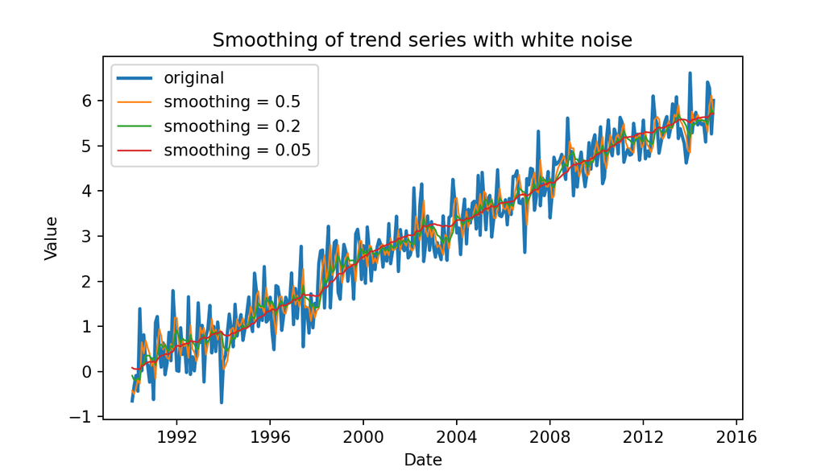